# factorMerger: set of tools to support results from post hoc testing

Agnieszka Sitko

2017-03-26

## Introduction

The aim of `factorMerger` is to provide set of tools to support results from post hoc comparisons. Post hoc testing is an analysis performed after running *ANOVA* to examine differences between group means (of some response numeric variable) for each pair of groups (groups are defined by a factor variable).

This project arose from the need to create a method of post hoc testing which gives the hierarchical interpretation of relations between groups means. Thereby, for a given significance level we may divide groups into nonoverlapping cluster.

## Algorithm inputs

Current version of `factorMerger` accepts **one-dimensional grouping variable** as independent variable only (multi-dimensional version is yet to be written; grouping variable is discrete). When it comes to dependent variable, `factorMerger` supports the following models:

- **gaussian** - either with one-dimensional or multivariate response,
- **binomial**,
- **survival**.

In each case we may specify whether in a single iteration of the algorithm test statistics are calculated for every possible pair of factor levels (cubic complexity) or only for “subsequent” pairs (quadratic complexity).

If the latter option is chosen factor variable is reordered before merging is performed. Order is determined on the basis of:

- groups means of the response variable for *one-dimensional gaussian model*,
- groups means of the vector fitted by non-metric multidimensional scaling for *multivariate gaussian model*,
- groups proportions of the response variable for *binomial model*,
- … for *survival model*.

## Generating samples

To visualize functionalities of `factorMerger` we use samples for which response variable is generated from one of the distributions listed above and corresponding factor variable is sampled uniformly from a finite set of a size $k$.

To do so, we may use function `generateSample` or `generateMultivariateSample`.

```r
set.seed(1)
library(factorMerger)
randSample <- generateMultivariateSample(N = 1000, k = 10, d = 3)
```

## Merging factors

`mergeFactors` is a function that performs hierarchical post hoc testing. As arguments it takes:

- matrix/data.frame/vector with numeric response,
- factor vector defining groups.

### Gaussian multi-dimensional response

#### Calculations

```r
fmAll <- mergeFactors(randSample$response, randSample$factor)
```

`mergeFactors` outputs with information about ‘merging history’.

```r
print(fmAll)
```

```
#> Family: gaussian Factor Merger.
#> Factor levels were recoded as below:
#>
#> recoded   original
#> --------  ---------
#> (B)       B
#> (F)       F
#> (G)       G
#> (J)       J
#> (C)       C
#> (H)       H
#> (A)       A
#> (D)       D
#> (E)       E
#> (I)       I
#>
#> Factor levels were merged in the following order:
#>
#> groupA                        groupB                       model     pval        AIC
#> ----------------------------  ----------------------  ----------  -------  ---------
#>                                                        -4303.661   1.0000   8627.322
#> (B)                           (F)                      -4303.769   0.9754   8625.538
#> (D)                           (A)                      -4304.107   0.9897   8624.214
#> (H)                           (C)                      -4304.566   0.9943   8623.131
#> (E)                           (I)                      -4305.068   0.9969   8622.136
#> (G)                           (B)(F)                   -4306.038   0.9943   8622.076
#> (D)(A)                        (H)(C)                   -4308.542   0.9420   8625.085
#> (D)(A)(H)(C)                  (G)(B)(F)                -4323.969   0.0074   8653.938
#> (E)(I)                        (D)(A)(H)(C)(G)(B)(F)    -4355.836   0.0000   8715.672
#> (E)(I)(D)(A)(H)(C)(G)(B)(F)   (J)                      -4395.580   0.0000   8793.160
```

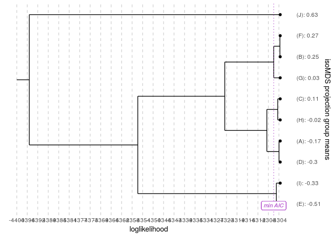

```r
plotTree(fmAll)
```

Each row of the above frame describes one step of the merging algorithm. First two columns specify which groups were merged in the iteration, column ‘model’ gathers some statistic calculated for the model after merging (e.g. in gaussian case loglikelihood is calculated), column ‘pval’ gives significance threshold below which hypothesis about means equality holds.

If we set `subsequent = TRUE` then at the beginning one dimensional response is fitted using `isoMDS{MASS}`. Then, in each step only groups whose means are closed are compared.

```r
fm <- mergeFactors(randSample$response, randSample$factor, subsequent = TRUE)
print(fm)
```

```
#> Family: gaussian Factor Merger.
#> Factor levels were recoded as below:
#>
#> recoded   original
#> --------  ---------
#> (B)       B
#> (F)       F
#> (G)       G
#> (J)       J
#> (C)       C
#> (H)       H
#> (A)       A
#> (D)       D
#> (E)       E
#> (I)       I
#>
#> Factor levels were merged in the following order:
#>
#> groupA                        groupB                       model     pval        AIC
#> ----------------------------  ----------------------  ----------  -------  ---------
#>                                                        -4303.661   1.0000   8627.322
#> (B)                           (F)                      -4303.769   0.9754   8625.538
#> (D)                           (A)                      -4304.107   0.9897   8624.214
#> (E)                           (I)                      -4304.609   0.9932   8623.218
#> (D)(A)                        (H)                      -4305.741   0.9811   8623.481
#> (D)(A)(H)                     (G)                      -4311.162   0.4626   8632.325
#> (D)(A)(H)(G)                  (C)                      -4312.746   0.4554   8633.492
#> (D)(A)(H)(G)(C)               (B)(F)                   -4323.969   0.0074   8653.938
#> (E)(I)                        (D)(A)(H)(G)(C)(B)(F)    -4355.836   0.0000   8715.672
#> (E)(I)(D)(A)(H)(G)(C)(B)(F)   (J)                      -4395.580   0.0000   8793.160
```

#### Visualizations

We may plot results using functions `plotTree`. `plotTree` enables to specify what should be displayed on x axis (either column ‘model’ or logarithm of ‘pval’).

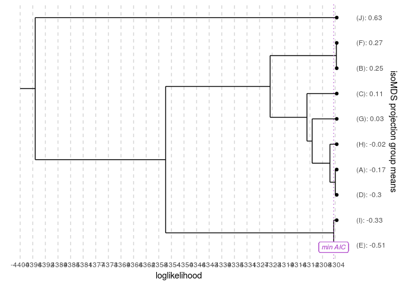

```r
plotTree(fm, stat = "model")
```

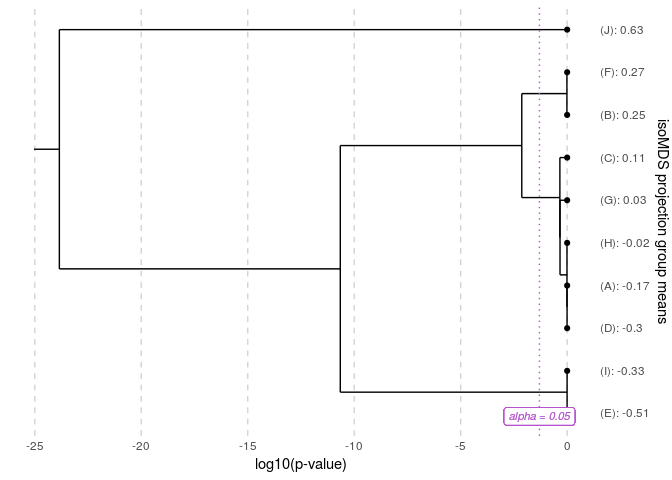

```r
plotTree(fm, "pval")
```

It also takes logical argument `simplify`, which controls how x axis is displayed. If `simplify = FALSE` then each node is connected the mean/mean of isoMDS projection/proportion of observations respresented by the node. Otherwise nodes are plotted using equal intervals on the x axis. As default we use `simplify = TRUE`.

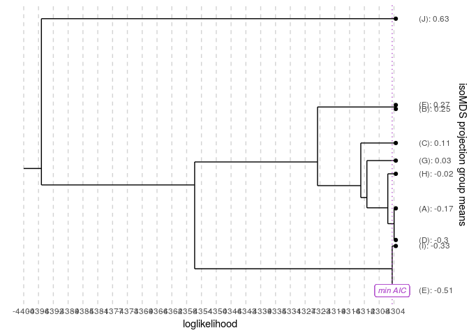

```r
plotTree(fm, simplify = FALSE)
```

We may also want to visualize dependent variables together with created tree. `factorMergers` introduces two functions for this purpose:

- `plotProfile` (resulting in rank plot),
- `plotHeatmap`.

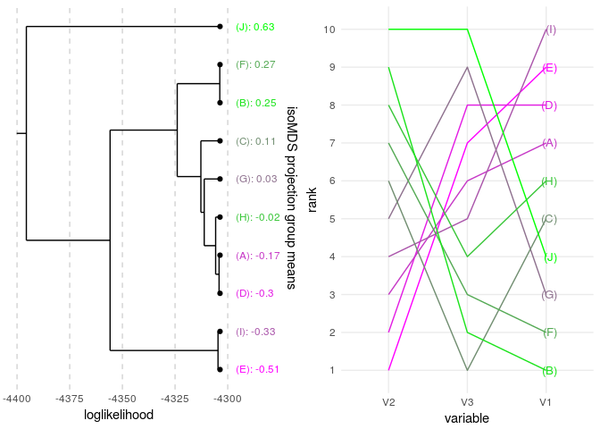

```r
appendToTree(fm, plotProfile(fm))
```

In the above plots colours are connected with the group. The plot on the right shows means rankings for all variables included in the algorithm.

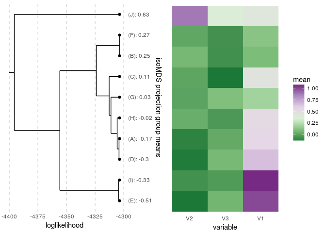

```r
appendToTree(fm, plotHeatmap(fm))
```

The heatmap on the right shows means of all variables taken into analysis by groups.

### One-dimensional gaussian response

```r
oneDimRandSample <- generateSample(1000, 10)
```

```r
oneDimFm <- mergeFactors(oneDimRandSample$response, oneDimRandSample$factor)
print(oneDimFm)
```

```
#> Family: gaussian Factor Merger.
#> Factor levels were recoded as below:
#>
#> recoded   original
#> --------  ---------
#> (I)       I
#> (J)       J
#> (A)       A
#> (F)       F
#> (C)       C
#> (B)       B
#> (H)       H
#> (G)       G
#> (E)       E
#> (D)       D
#>
#> Factor levels were merged in the following order:
#>
#> groupA            groupB                          model     pval        AIC
#> ----------------  -------------------------  ----------  -------  ---------
#>                                               -1429.195   1.0000   2878.391
#> (B)               (H)                         -1429.195   0.9974   2876.391
#> (G)               (E)                         -1429.196   0.9996   2874.392
#> (C)               (B)(H)                      -1429.218   0.9975   2872.436
#> (C)(B)(H)         (G)(E)                      -1429.335   0.9913   2870.670
#> (I)               (J)                         -1429.531   0.9848   2869.062
#> (C)(B)(H)(G)(E)   (D)                         -1429.961   0.9583   2867.921
#> (A)               (F)                         -1431.614   0.6841   2869.229
#> (A)(F)            (C)(B)(H)(G)(E)(D)          -1440.105   0.0056   2884.211
#> (I)(J)            (A)(F)(C)(B)(H)(G)(E)(D)    -1492.466   0.0000   2986.931
```

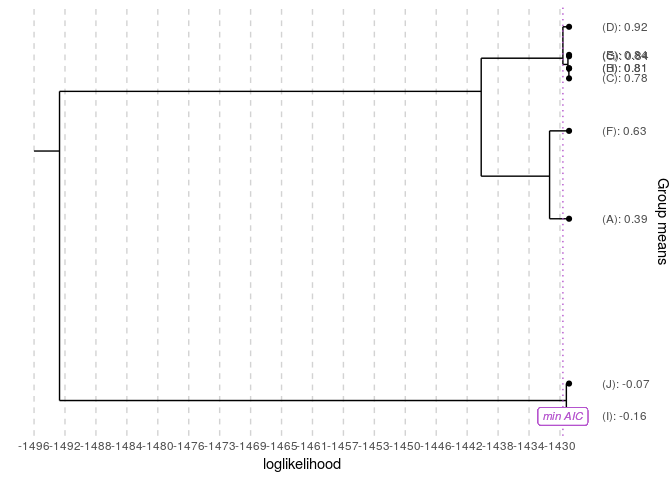

```r
plotTree(oneDimFm, simplify = FALSE)
```

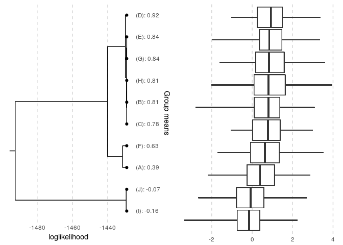

```r
appendToTree(oneDimFm, plotBoxplot(oneDimFm))
```

### Binomial response

```r
binomRandSample <- generateSample(1000, 10, distr = "binomial")
table(binomRandSample$response, binomRandSample$factor)
```

```
#>
#>      C  H  I  G  A  D  B  E  J  F
#>   0 97 82 97 84 71 52 51 53 31 18
#>   1  6  7 15 21 40 35 44 46 75 75
```

```r
binomFm <- mergeFactors(binomRandSample$response, binomRandSample$factor, family = "binomial", subsequent = TRUE)
print(binomFm)
```

```
#> Family: binomial Factor Merger.
#> Factor levels were recoded as below:
#>
#> recoded   original
#> --------  ---------
#> (C)       C
#> (H)       H
#> (I)       I
#> (G)       G
#> (A)       A
#> (D)       D
#> (B)       B
#> (E)       E
#> (J)       J
#> (F)       F
#>
#> Factor levels were merged in the following order:
#>
#> groupA                     groupB              model     pval        AIC
#> -------------------------  -------------  ----------  -------  ---------
#>                                            -518.9443   1.0000   1057.889
#> (B)                        (E)             -518.9446   0.9834   1055.889
#> (C)                        (H)             -519.1014   0.8546   1054.203
#> (A)                        (D)             -519.2835   0.8783   1052.567
#> (A)(D)                     (B)(E)          -520.7419   0.4636   1053.484
#> (C)(H)                     (I)             -522.5291   0.2083   1055.058
#> (C)(H)(I)                  (G)             -526.4556   0.0201   1060.911
#> (J)                        (F)             -527.7760   0.0136   1061.552
#> (C)(H)(I)(G)               (A)(D)(B)(E)    -575.9894   0.0000   1155.979
#> (C)(H)(I)(G)(A)(D)(B)(E)   (J)(F)          -655.6850   0.0000   1313.370
```

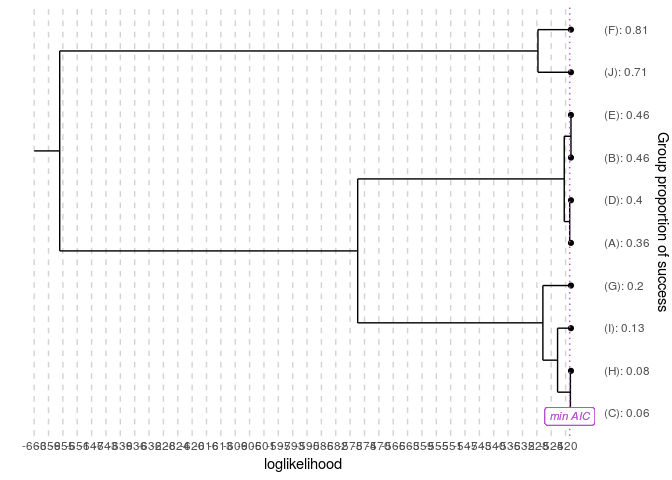

```r
plotTree(binomFm)
```

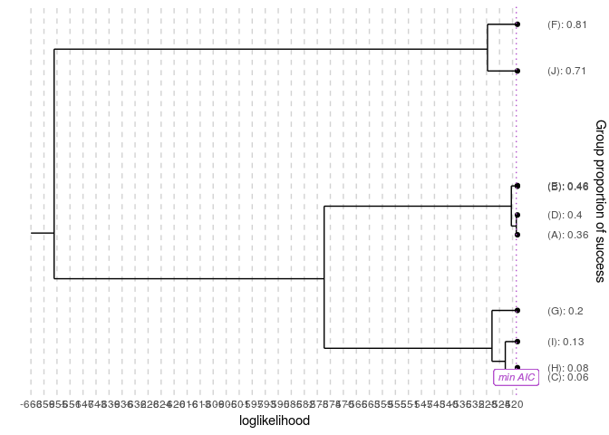

```r
plotTree(binomFm, simplify = FALSE)
```

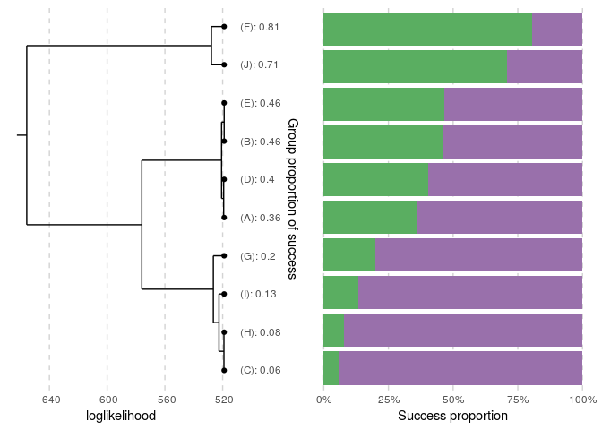

```r
appendToTree(binomFm, plotProportion(binomFm))
```

### Survival model

```r
library(survival)
data(veteran)
survivalFm <- mergeFactors(response = subset(veteran, select = c(time, status)),
                   factor = veteran$celltype,
                   family = "survival")
```

```r
survivalFm <- mergeFactors(response = subset(veteran, select = c(time, status)),
                   factor = veteran$celltype,
                   subsequent = TRUE,
                   family = "survival")
```

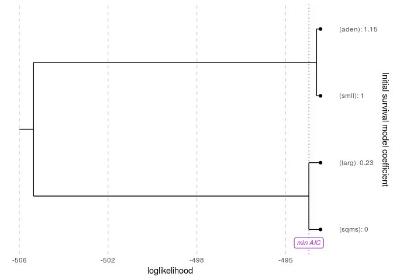

```r
plotTree(survivalFm, "model")
```

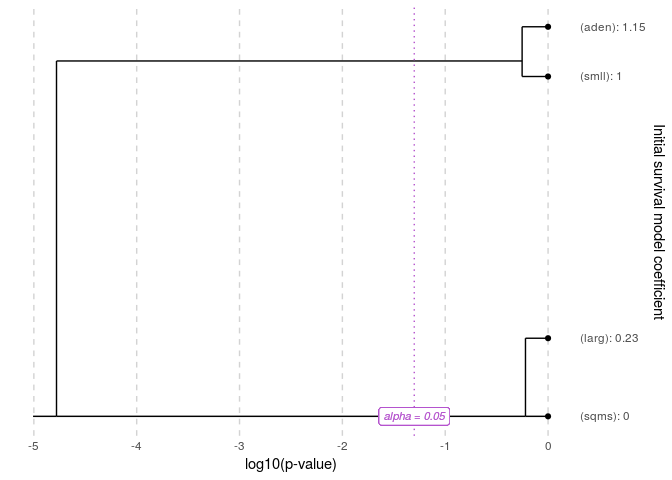

```r
plotTree(survivalFm, "pval", simplify = FALSE)
```

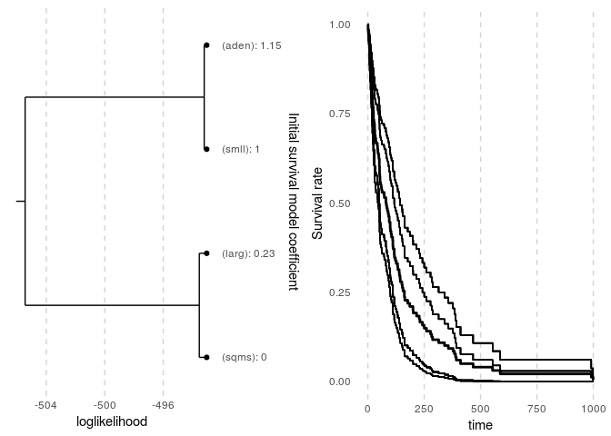

```r
appendToTree(survivalFm, plotSurvival(survivalFm))
```